# Introduction to Rcpp

January 19, 2020

## Overview

- Introduction
- cppFunction() / sourceCpp()
- Sugar functions
- Example with speed comparison

**Slides are based on the *Rcpp* chapter by Wickham (2019) and best enjoyed in fullscreen (F11 in Google Chrome).**

## Introduction: What is Rcpp?

- R package created by Dirk Eddelbuettel and Romain François (main contributors) in 2011
- allows for *easy* integration of C++ and R
- generally possible to integrate code from other languages into R as well (e.g. Fortran), but it is a lot more complicated

```r
library(Rcpp)
```

## Introduction: One step back - what is C++?

- general purpose programming language
- created by Bjarne Strousstrup in 1979
- extension of the C
- **close to machine code = runs (very) fast!**

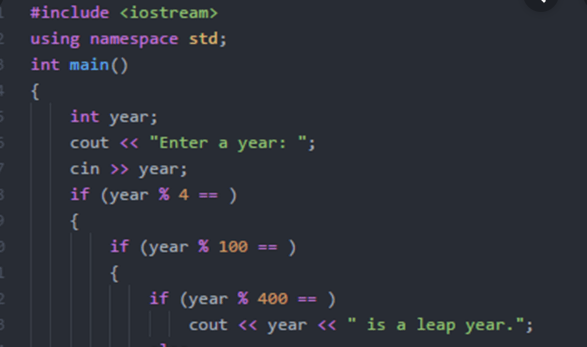

## Introduction: Why Rcpp?

*“Code written using Rcpp classes is easier to read, write and maintain, without losing performance.”* (Eddelbuettel & François, 2017)

- To optimize your R code (overcome bottlenecks)
- Code runs faster than R code
- Code is (hopefully) easy to write (see sugar functions)

## Use cases for Rcpp

Typical bottlenecks that C++ can address include:

- Loops where subsequent iterations depend on previous ones
- Recursive functions and functions that are called many times (overhead of calling function in C++ is much lower)
- Problems that involve data structures and algorithms that R doesn’t provide (implementation of important data structures in C++ through the standard template library)

## A first example using Rcpp::cppFunction()

1. Pass C++ code to the `cppFunction`
2. Use the newly created function just like any other R function

```r
library(Rcpp)

cppFunction('int addC(int x, int y, int z) {
  int sum = x + y + z;
  return sum;
}')

addC(1, 2, 3)
```

```
## [1] 6
```

## Another example using Rcpp::cppFunction() 1/2

Implementing a function that calculates row sums:

```r
cppFunction('NumericVector rowSumsC(NumericMatrix x) {
  int nrow = x.nrow(), ncol = x.ncol();
  NumericVector out(nrow);

  for (int i = 0; i < nrow; i++) {
    double total = 0;
    for (int j = 0; j < ncol; j++) {
      total += x(i, j);
    }
    out[i] = total;
  }
  return out;
}')
```

## Another example using Rcpp::cppFunction() 2/2

```r
set.seed(42)
x <- matrix(sample(100), 10)

# "official" R implementation
rowSums(x)
```

```
##  [1] 425 509 528 390 570 511 535 373 499 710
```

```r
# Rcpp implementation
rowSumsC(x)
```

```
##  [1] 425 509 528 390 570 511 535 373 499 710
```

## Rcpp::sourceCpp() 1/3

- `sourceCpp`: Function used to source C++ files into R
- the usual workflow when working on “real world problems”

**Important:**

```cpp
/* Your stand alone C++ file (*.cpp) should always start with: */
#include <Rcpp.h>
using namespace Rcpp;

/* Prefix each function that you want available within R with */
// [[Rcpp::export]]
```

## Rcpp::sourceCpp() 2/3

Your C++ file should look like this:

```cpp
#include <Rcpp.h>
using namespace Rcpp;

// [[Rcpp::export]]
double meanC(NumericVector x) {
  int n = x.size();
  double total = 0;

  for(int i = 0; i < n; ++i) {
    total += x[i];
  }
  return total / n;
}
```

## Rcpp::sourceCpp() 3/3

- use `sourceCpp("path/to/file.cpp")` to compile the C++ code
- creates corresponding R function(s) and adds them to your session
- note: functions must be recreated everytime you restart R (can’t be saved in `.Rdata`)

```r
sourceCpp("path/to/file.cpp")
```

## Rcpp sugar functions 1/3

- ensure that functions work very similarly to their R equivalents
- make it possible to write efficient C++ code that looks almost identical to its R equivalent
- keyword **vectorization**
- if there’s a sugar version of a function, use it!

```cpp
mean(some_vector)
```

## Rcpp sugar functions 2/3

| Category | Examples |
| --- | --- |
| arithmetic / logical operators | `+`, `*`, `-` |
| logical summary functions | `any()`, `all()` |
| vector views | `head(), tail()` |
| other useful functions | `abs()`, `mean()` |

## Rcpp sugar functions 3/3

```r
# R function:
pdistR <- function(x, ys) {
  sqrt((x - ys) ^ 2)
}
```

```cpp
/* Rcpp equivalent (note sqrt, pow, -): */
#include <Rcpp.h>
using namespace Rcpp;

// [[Rcpp::export]]
NumericVector pdistC2(double x, NumericVector ys) {
  return sqrt(pow((x - ys), 2));
}
```

## Case study with speed comparison: Gibbs sampler 1/3

```r
gibbs_r <- function(N, thin) {
  mat <- matrix(nrow = N, ncol = 2)
  x <- y <- 0

  for (i in 1:N) {
    for (j in 1:thin) {
      x <- rgamma(1, 3, y * y + 4)
      y <- rnorm(1, 1 / (x + 1), 1 / sqrt(2 * (x + 1)))
    }
    mat[i, ] <- c(x, y)
  }
  mat
}
```

## Case study with speed comparison: Gibbs sampler 2/3

```r
cppFunction('NumericMatrix gibbs_cpp(int N, int thin) {
               NumericMatrix mat(N, 2);
               double x = 0, y = 0;

               for(int i = 0; i < N; i++) {
                 for(int j = 0; j < thin; j++) {
                   x = rgamma(1, 3, 1 / (y * y + 4))[0];
                   y = rnorm(1, 1 / (x + 1), 1 / sqrt(2 * (x + 1)))[0];
                 }
                 mat(i, 0) = x;
                 mat(i, 1) = y;
               }

               return(mat);
             }'
           )
```

## Case study with speed comparison: Gibbs sampler 3/3

```r
library(microbenchmark)

microbenchmark(gibbs_r(100, 10),
               gibbs_cpp(100, 10))
```

```
## Unit: microseconds
##                expr      min       lq      mean   median        uq       max
##    gibbs_r(100, 10) 3296.262 3335.755 4084.2478 3391.115 3551.3810 13668.837
##  gibbs_cpp(100, 10)  191.471  201.521  223.3339  207.692  214.3915  1271.184
##  neval
##    100
##    100
```

## There’s more…

- this presentation only covered some core functionalities of `Rcpp`
- there is a lot more interesting stuff…
  - `Rcpp` in R packages
  - data structures, attributes, missing values in `Rcpp`
  - …
- see the references for further sources

## References

- Eddelbuettel, D., & François, R. (2011). Rcpp: Seamless R and C++ Integration. *Journal of Statistical Software, 40*(8), 1-18. Retrieved from http://www.jstatsoft.org/v40/i08/
- Eddelbuettel, D., & François, R. (2011). *Rcpp syntatic sugar*. Retrieved from http://dirk.eddelbuettel.com/code/rcpp/Rcpp-sugar.pdf.
- Wickham, H. (2019). Rewriting R code in C++. *Advanced R*. Retrieved from https://adv-r.hadley.nz/rcpp.html